# 数据挖掘简介

### 什么是数据挖掘

数据挖掘一般是指从大量的数据中通过算法搜索隐藏于其中信息的过程。数据挖掘通常与计算机科学有关，并通过统计、在线分析处理、情报检索、机器学习、专家系统（依靠过去的经验法则）和模式识别等诸多方法来实现上述目标。

### 为什么会出现数据挖掘

互联网，物联网时代，产生了大量的数据，大数据的存储技术的成熟，使用数据挖据成为可能，并且迫切需要将这些数据转换成有用的信息和知识。获取的信息和知识可以广泛用于各种应用，包括商务管理，生产控制，市场分析，工程设计和科学探索等。

### 一些数据挖掘的案例

- 全球零售业巨头沃尔玛在对消费者购物行为分析时发现，男性顾客在购买婴儿尿片时，常常会顺便搭配几瓶啤酒来犒劳自己，于是尝试推出了将啤酒和尿布摆在一起的促销手段。没想到这个举措居然使尿布和啤酒的销量都大幅增加了。如今，“啤酒＋尿布”的数据分析成果早已成了大数据技术应用的经典案例，被人津津乐道。
- 2009年，Google通过分析5000万条美国人最频繁检索的词汇，将之和美国疾病中心在2003年到2008年间季节性流感传播时期的数据进行比较，并建立一个特定的数学模型。最终google成功预测了2009冬季流感的传播甚至可以具体到特定的地区和州。
- 2013年，微软纽约研究院的经济学家大卫•罗斯柴尔德（David Rothschild）利用大数据成功预测24个奥斯卡奖项中的19个，成为人们津津乐道的话题。今年罗斯柴尔德再接再厉，成功预测第86届奥斯卡金像奖颁奖典礼24个奖项中的21个，继续向人们展示现代科技的神奇魔力
- 电商行业的现金收入源自数据，而婚恋网站的商业模型更是根植于对数据的研究。比如，作为一家婚恋网站，百合网不仅需要经常做一些研究报告，分析注册用户的年龄、地域、学历、经济收入等数据，即便是每名注册用户小小的头像照片，这背后也大有挖掘的价值。百合网研究规划部李琦曾经对百合网上海量注册用户的头像信息进行分析，发现那些受欢迎头像照片不仅与照片主人的长相有关，同时照片上人物的表情、脸部比例、清晰度等因素也在很大程度上决定了照片主人受欢迎的程度。例如，对于女性会员，微笑的表情、直视前方的眼神和淡淡的妆容能增加自己受欢迎的概率，而那些脸部比例占照片1/2、穿着正式、眼神直视没有多余pose的男性则更可能成为婚恋网站上的宠儿。
- 银行客户群体划分

### 数据挖据分类

- 分类
> 1. 首先从数据中选出已经分好类的训练集，在该训练集上运用数据挖掘分类的技术，建立分类模型，对于没有分类的数据进行分类。
> 2. 常用方法：决策树、贝叶斯、逻辑回归、神经网络
> 3. 例子：信用卡申请者，分类为低、中、高风险
- 聚类
> 1. 聚类是对记录分组，把相似的记录在一个聚集里。聚类和分类的区别是聚集不依赖于预先定义好的类，不需要训练集。
> 2. 常用方法:K-Means ，分层凝聚发估算最大法（EM）
> 3. 例子：用户分类
- 关联
> 1. 决定哪些事情将一起发生。
> 2. 常用方法: apriori
> 3. 例子：超市中客户在购买A的同时，经常会购买B，即A => B(关联规则)、客户在购买A后，隔一段时间，会购买B （序列分析）
- 预测
> 1. 利用历史数据找出变化规律，建立模型，并用此模型来预测未来数据的特征。
> 2. 常用方法：决策树、贝叶斯
> 3. 例子：传染病爆发预测

# 数据挖掘经典算法

IEEE选出实际中用途最广、影响最大的十种数据挖掘算法

> 1. C4.5：是机器学习算法中的一种分类决策树算法，其核心算法是ID3算法。
> 2. K-means算法：是一种聚类算法。
> 3. SVM：一种监督式学习的方法，广泛运用于统计分类以及回归分析中
> 4. Apriori ：是一种最有影响的挖掘布尔关联规则频繁项集的算法。
> 5. EM：最大期望值法。
> 6. pagerank：是google算法的重要内容。
> 7. Adaboost:是一种迭代算法，其核心思想是针对同一个训练集训练不同的分类器然后把弱分类器集合起来，构成一个更强的最终分类器。
> 8. KNN:是一个理论上比较成熟的的方法，也是最简单的机器学习方法之一。
> 9. Naive Bayes：在众多分类方法中，应用最广泛的有决策树模型和朴素贝叶斯（Naive Bayes）
> 10. Cart：分类与回归树，在分类树下面有两个关键的思想，第一个是关于递归地划分自变量空间的想法，第二个是用验证数据进行减枝。

# 数据挖据实例

### 1. 关联分析

从大量数据中发现项集之间的有趣关联或者相互关系

#### 1. 实例

京东购物推荐

[figure not shown]

购物推荐 - 尿片

[figure not shown]

购物推荐 - 鼠标

#### 2. 相关概念

> 1. 关联规则，一般记为 X->Y 的形式,称关联规则左侧的项集X为先决条件，右侧项集Y为相应的关联结果，关联的强度由三个核心概念定义
> 2. 支持度：即所有项集中{X,Y}出现的可能性，即项集中同时含有X，Y的概率

> > Support(X->Y)=P(X,Y)

> 可以通过最小阈值过滤出现率比较低项集： Support(Z)>min_support 的项集Z，被称为频繁项集
> 3. 置信度：表示先决条件X发生的条件下，关联结果Y发生的概率，即含有X的项集中，同时含有Y的可能性

> > Confidence(X->Y)=P(Y|X)=P(X,Y)/P(X)

> 这是生成强关联规则的第二个门槛
> 4. 提升度：含有X条件下同时含有Y的可能与没有这个条件下项集中含有Y的可能性之比

> > Lift(X->Y)=P(Y|X)/P(Y) = confidence(X->Y)/P(Y)

#### 3. 例子（Apriori）

> 算法： Apriori的原理是如果某个项集是频繁的，那么它的子集也是频繁的。反过来说，如果一个项集是非频繁的，那么它的所有超集也是非频繁的。比如{1,2}出现的次数已经小于最小支持度了(非频繁的)，那么超集{0,1,2}的组合肯定也是非频繁的了。主要包括发现频繁项集和挖掘关联规则这两步。

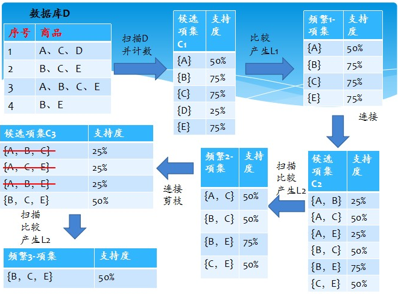

apriori算法过程

1. 输出商品关联度

```r
options(digits = 3)
library(arules)
data("Groceries")
summary(Groceries)
```

```
     transactions as itemMatrix in sparse format with
      9835 rows (elements/itemsets/transactions) and
      169 columns (items) and a density of 0.0261

     most frequent items:
           whole milk other vegetables       rolls/buns             soda
                 2513             1903             1809             1715
               yogurt          (Other)
                 1372            34055

     element (itemset/transaction) length distribution:
     sizes
        1    2    3    4    5    6    7    8    9   10   11   12   13   14   15
     2159 1643 1299 1005  855  645  545  438  350  246  182  117   78   77   55
       16   17   18   19   20   21   22   23   24   26   27   28   29   32
       46   29   14   14    9   11    4    6    1    1    1    1    3    1

        Min. 1st Qu.  Median    Mean 3rd Qu.    Max.
         1.0     2.0     3.0     4.4     6.0    32.0

     includes extended item information - examples:
            labels  level2           level1
     1 frankfurter sausage meat and sausage
     2     sausage sausage meat and sausage
     3  liver loaf sausage meat and sausage
```

```r
#数据解析：数据含有9835行，表示有9835条交易记录，含有169列，每列表示一个商品
# 其中购买频率比较高的商品
# whole milk other        vegetables       rolls/buns             soda
#            2513             1903             1809             1715
#          yogurt          (Other)
#            1372            34055


inspect(Groceries[1:10])
```

```
        items
     1  {citrus fruit,
         semi-finished bread,
         margarine,
         ready soups}
     2  {tropical fruit,
         yogurt,
         coffee}
     3  {whole milk}
     4  {pip fruit,
         yogurt,
         cream cheese ,
         meat spreads}
     5  {other vegetables,
         whole milk,
         condensed milk,
         long life bakery product}
     6  {whole milk,
         butter,
         yogurt,
         rice,
         abrasive cleaner}
     7  {rolls/buns}
     8  {other vegetables,
         UHT-milk,
         rolls/buns,
         bottled beer,
         liquor (appetizer)}
     9  {pot plants}
     10 {whole milk,
         cereals}
```

```r
#可以查看每位顾客购买的商品



rules0<-apriori(Groceries,parameter = list(maxlen=3,support=.005,confidence=.5))
```

```
     Apriori

     Parameter specification:
      confidence minval smax arem  aval originalSupport support minlen maxlen
             0.5    0.1    1 none FALSE            TRUE   0.005      1      3
      target   ext
       rules FALSE

     Algorithmic control:
      filter tree heap memopt load sort verbose
         0.1 TRUE TRUE  FALSE TRUE    2    TRUE

     Absolute minimum support count: 49

     set item appearances ...[0 item(s)] done [0.00s].
     set transactions ...[169 item(s), 9835 transaction(s)] done [0.00s].
     sorting and recoding items ... [120 item(s)] done [0.00s].
     creating transaction tree ... done [0.00s].
     checking subsets of size 1 2 3 done [0.00s].
     writing ... [99 rule(s)] done [0.00s].
     creating S4 object  ... done [0.00s].
```

```r
inspect(sort(rules0,by="confidence")[1:10])
```

```
        lhs                               rhs          support confidence lift
     43 {butter,whipped/sour cream}    => {whole milk} 0.00671 0.660      2.58
     67 {pip fruit,whipped/sour cream} => {whole milk} 0.00600 0.648      2.54
     50 {butter,yogurt}                => {whole milk} 0.00935 0.639      2.50
     49 {root vegetables,butter}       => {whole milk} 0.00824 0.638      2.50
     22 {tropical fruit,curd}          => {whole milk} 0.00651 0.634      2.48
     56 {pip fruit,domestic eggs}      => {whole milk} 0.00539 0.624      2.44
     47 {tropical fruit,butter}        => {whole milk} 0.00620 0.622      2.44
     38 {domestic eggs,margarine}      => {whole milk} 0.00519 0.622      2.43
     41 {butter,domestic eggs}         => {whole milk} 0.00600 0.621      2.43
     58 {tropical fruit,domestic eggs} => {whole milk} 0.00691 0.607      2.38
```

```r
#按照关联度进行排序
```

2. 查找某样商品的强关联商品

```r
rules1<-apriori(Groceries,parameter = list(maxlen=2,support=.001,confidence=.1),appearance = list(rhs="mustard",default="lhs"))
```

```
     Apriori

     Parameter specification:
      confidence minval smax arem  aval originalSupport support minlen maxlen
             0.1    0.1    1 none FALSE            TRUE   0.001      1      2
      target   ext
       rules FALSE

     Algorithmic control:
      filter tree heap memopt load sort verbose
         0.1 TRUE TRUE  FALSE TRUE    2    TRUE

     Absolute minimum support count: 9

     set item appearances ...[1 item(s)] done [0.00s].
     set transactions ...[169 item(s), 9835 transaction(s)] done [0.00s].
     sorting and recoding items ... [157 item(s)] done [0.00s].
     creating transaction tree ... done [0.00s].
     checking subsets of size 1 2 done [0.01s].
     writing ... [1 rule(s)] done [0.00s].
     creating S4 object  ... done [0.00s].
```

```r
inspect(rules1)
```

```
       lhs             rhs       support confidence lift
     1 {mayonnaise} => {mustard} 0.00142 0.156      13
```

```r
#蛋黄酱跟芥末的关联度比较高，促销活动时，可以将蛋黄酱跟芥末进行捆绑销售
```

3. 可视化输出

```
     Apriori

     Parameter specification:
      confidence minval smax arem  aval originalSupport support minlen maxlen
             0.5    0.1    1 none FALSE            TRUE   0.002      1     10
      target   ext
       rules FALSE

     Algorithmic control:
      filter tree heap memopt load sort verbose
         0.1 TRUE TRUE  FALSE TRUE    2    TRUE

     Absolute minimum support count: 19

     set item appearances ...[0 item(s)] done [0.00s].
     set transactions ...[169 item(s), 9835 transaction(s)] done [0.00s].
     sorting and recoding items ... [147 item(s)] done [0.00s].
     creating transaction tree ... done [0.01s].
     checking subsets of size 1 2 3 4 5 done [0.01s].
     writing ... [1098 rule(s)] done [0.00s].
     creating S4 object  ... done [0.03s].
```

```
     set of 1098 rules
```

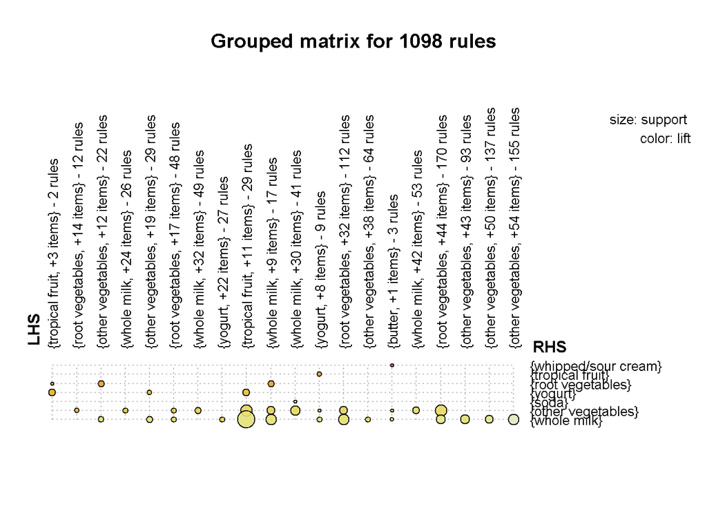

### 2. 判别分析

根据已有的数据，对未知的数据进行类型判别、分类

#### 1. 相关概念

> KNN 算法，就是k个最近的邻居的意思，说的是每个样本都可以用它最接近的k个邻居来代表。kNN算法的核心思想是如果一个样本在特征空间中的k个最相邻的样本中的大多数属于某一个类别，则该样本也属于这个类别，并具有这个类别上样本的特性。

#### 2. 例子（电影评分推荐）

> 1. 目的： 预测某位用户，对某部电影（M0）的评分
> 2. 步骤
> > 1. 选择用户（U0）已经给出评分的电影，获取n部，并获取电影ID,记为M1-Mn
> > 2. 找出对电影M0已经进行过评分的用户，假设有m位，并获取id，记为U1-Um
> > 3. 利用以上获取的三组ID，构造训练集和测试集
> > 4. 将相应的训练集与测试集进行knn分类，预测出用户U0对电影M0的评分。
> > 5. 所用距离基于欧氏距离
> 3. 数据信息：1000个用户，10万条评分记录，评分值为（1~5）

```r
library(class)
data<-read.table("D:/Documents/ml-100k/u.data")
data<-data[,-4]
names(data)<-c('userid','itemid','rating')
head(data,10)
```

```
        userid itemid rating
     1     196    242      3
     2     186    302      3
     3      22    377      1
     4     244     51      2
     5     166    346      1
     6     298    474      4
     7     115    265      2
     8     253    465      5
     9     305    451      3
     10      6     86      3
```

```r
# 数据结构  user ， moive ， rating

# 主函数
# 参数  用户id ， 电影id ， 获取电影评分数量 ，最近的用户数量

MovieRating_KNN<-function(userId,itemId,n,K){

  #随机抽样用户评分的n部电影
  sub<-which(data$userid==userId)
  if(length(sub)>=n){
    sub_n<-sample(sub,n)
  } else {
    sub_n<-sample(sub,length(sub))
  }

  known_itemid<-data$itemid[sub_n]
  unknow_itemid<-itemId

  #所有对目标电影评过分记录
  unknow_sub<-which(data$itemid==unknow_itemid)
  user<-data$userid[unknow_sub[-1]]


  #创建成数据框
  data_all<-matrix(0,1+length(user),2+length(known_itemid))
  data_all<-data.frame(data_all)

  names(data_all)<-c('userid',paste('unknow_itemid_',itemId),paste("itemid_",known_itemid,sep=""))

  item<-c(unknow_itemid,known_itemid)

  data_all$userid<-c(userId,user)


  #对data_all 赋值
  for(i in 1: nrow(data_all)){
    data_temp<-data[which(data$userid==data_all$userid[i]),]
    for(j in 1: length(item)){
      if(sum(as.numeric(data_temp$itemid==item[j]))!=0){ #对应项有值
        data_all[i,j+1]<-data_temp$rating[which(data_temp$itemid==item[j])]
      }
    }
  }


  data_test_x<-data_all[1,c(-1:-2)]
  data_test_y<-data_all[1,2]

  data_train_x<-data_all[-1,c(-1,-2)]
  data_train_y<-data_all[-1,2]


  fit<-knn(data_train_x,data_test_x,cl=data_train_y,k=K)

  l<-list("data_all"=data_all,"True Rating"=data_test_y,
          "Predict RAting"=fit,"UserID"=userId,"ItemID"=itemId)
  return(l)
}

p<-''
length<-20
diff<-0
for(Item in 1:20){
  result<-MovieRating_KNN(userId = 1,itemId = Item,n = 50,K=10)
  p<-c(p,paste("userid:",result$`UserID`,",True Rating:",result$`True Rating`,",predict rating",result$`Predict RAting`))
  diff<- diff + abs(as.integer(result$`True Rating`)-as.integer(result$`Predict RAting`))
}

print(p)
```

```
      [1] ""
      [2] "userid: 1 ,True Rating: 5 ,predict rating 2"
      [3] "userid: 1 ,True Rating: 3 ,predict rating 3"
      [4] "userid: 1 ,True Rating: 4 ,predict rating 4"
      [5] "userid: 1 ,True Rating: 3 ,predict rating 4"
      [6] "userid: 1 ,True Rating: 3 ,predict rating 3"
      [7] "userid: 1 ,True Rating: 5 ,predict rating 4"
      [8] "userid: 1 ,True Rating: 4 ,predict rating 4"
      [9] "userid: 1 ,True Rating: 1 ,predict rating 3"
     [10] "userid: 1 ,True Rating: 5 ,predict rating 5"
     [11] "userid: 1 ,True Rating: 3 ,predict rating 4"
     [12] "userid: 1 ,True Rating: 2 ,predict rating 4"
     [13] "userid: 1 ,True Rating: 5 ,predict rating 5"
     [14] "userid: 1 ,True Rating: 5 ,predict rating 4"
     [15] "userid: 1 ,True Rating: 5 ,predict rating 4"
     [16] "userid: 1 ,True Rating: 5 ,predict rating 3"
     [17] "userid: 1 ,True Rating: 5 ,predict rating 4"
     [18] "userid: 1 ,True Rating: 3 ,predict rating 4"
     [19] "userid: 1 ,True Rating: 4 ,predict rating 3"
     [20] "userid: 1 ,True Rating: 5 ,predict rating 3"
     [21] "userid: 1 ,True Rating: 4 ,predict rating 4"
```

```r
# 求出 user1 对电影的真实评分及对电影的预测评分

print(diff/length)
```

```
     [1] 0.95
```

```r
#平均每部电影的差值
```

### 3. PageRank

主要用于网页搜素排序

#### 1. 相关概念

> 1. 早期的搜索引擎是根据关键词出现次数对网页进行排序,如果网页多次重复关键词，就可以排在前面，排序不合理
> 2. 网页的重要性是不能靠每个网页自己来标榜的，而应该通过全互联网所有网页间的相互链接来确定,一个网页被其它网页链接得越多， 它的排序就应该越靠前,一个网页越是被排序靠前的网页所链接，它的排序就也应该越靠前
> 3. 数量假设：如果一个页面节点接收到的其他网页指向的入链数量越多，那么这个页面越重要
> 4. 质量假设：指向页面A的入链质量不同，质量高的页面会通过链接向其他页面传递更多的权重。所以越是质量高的页面指向页面A，则页面A越重要
> 5. 计算公式： 其中

> > PR(pi): pi页面的PageRank值 n: 所有页面的数量 pi: 不同的网页p1,p2,p3 M(i): pi链入网页的集合 L(j): pj链出网页的数量 d:阻尼系数, 任意时刻，用户到达某页面后并继续向后浏览的概率。 (1-d=0.15) :表示用户停止点击，随机跳到新URL的概率 取值范围: 0 < d ≤ 1, Google设为0.85

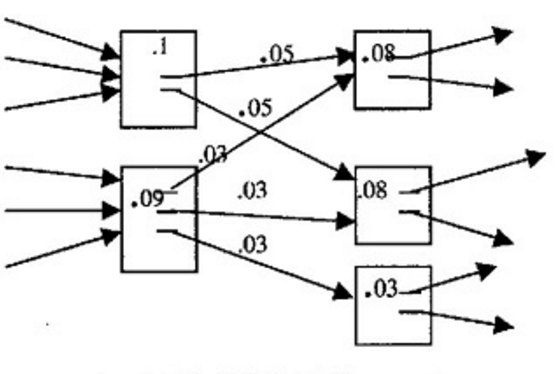

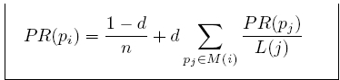

pageRank公式

> 随着每增加一次访问，pageRank都会更新，PageRank值在有限次递归后会收敛，收敛后的值就是最终值

#### 2. 例子

本例子假设用户上网只能从一个网页点击链接跳到另外一个网页，即d=1

```r
options(digits = 4)



#构造方程系数矩阵

transferMatrix_withoutD<-function(G){
  for(i in 1:nrow(G)){
    n<-length(which(G[i,]!=0))
    G[i,]<-G[i,]/n
  }
  return(G)
}

getRank<-function(G,iter=10){
  n<-ncol(G)
  # 初始化等概率向量
  x<-rep(1/n,n)
  for(i in 1 : iter){
    x<- G %*% x
  }
  return(x)
}

transferMatrix_withD<-function(G,d=0.85){
  cs <- colSums(G)
  cs[cs==0] <- 1
  n <- nrow(G)
  delta <- (1-d)/n
  A <- matrix(delta,nrow(G),ncol(G))
  for (i in 1:n) A[i,] <- A[i,] + d*G[i,]/cs
  return(A)
}


a_matrix<-t(matrix(c(0,1,1,1,0,0,1,1,0,0,0,1,0,1,0,0),nrow = 4))
a_matrix
```

```
          [,1] [,2] [,3] [,4]
     [1,]    0    1    1    1
     [2,]    0    0    1    1
     [3,]    0    0    0    1
     [4,]    0    1    0    0
```

```r
# 每一行代表每个网页的链接情况 ， 第一行表示第一网页链接到 第二，第三，第四个网页

a_matrix<-transferMatrix_withoutD(a_matrix)
a_matrix<-t(a_matrix)

a_matrix
```

```
            [,1] [,2] [,3] [,4]
     [1,] 0.0000  0.0    0    0
     [2,] 0.3333  0.0    0    1
     [3,] 0.3333  0.5    0    0
     [4,] 0.3333  0.5    1    0
```

```r
# 转移矩阵

getRank(a_matrix)
```

```
            [,1]
     [1,] 0.0000
     [2,] 0.4036
     [3,] 0.1979
     [4,] 0.3984
```

```r
#得出 4个网页的pagerank值

#---------------------带d值------------------------------

a_matrix<-matrix(c(0,1,1,1,0,0,1,1,0,0,0,1,0,1,0,0),nrow = 4)
a_matrix
```

```
          [,1] [,2] [,3] [,4]
     [1,]    0    0    0    0
     [2,]    1    0    0    1
     [3,]    1    1    0    0
     [4,]    1    1    1    0
```

```r
a_matrix<-transferMatrix_withD(a_matrix)

a_matrix
```

```
            [,1]   [,2]   [,3]   [,4]
     [1,] 0.0375 0.0375 0.0375 0.0375
     [2,] 0.3208 0.0375 0.0375 0.8875
     [3,] 0.3208 0.4625 0.0375 0.0375
     [4,] 0.3208 0.4625 0.8875 0.0375
```

```r
# 转移矩阵(带有D的转移矩阵)

getRank(a_matrix)
```

```
            [,1]
     [1,] 0.0375
     [2,] 0.3739
     [3,] 0.2064
     [4,] 0.3822
```

```r
#得出 4个网页的pagerank值(带D值)
```

#### 3. 并行计算

单机计算量有限，可以在hadoop中用mapreduce进行运算

> 1. 第一个mapreduce任务进行转移矩阵的构建

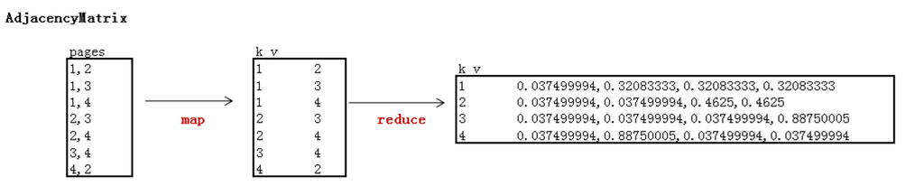

pageRank–mapreduce

> 2. 第二个mapreduce计算pagerank值，每运行一次等于重新计算一次pagerank值，直至收敛

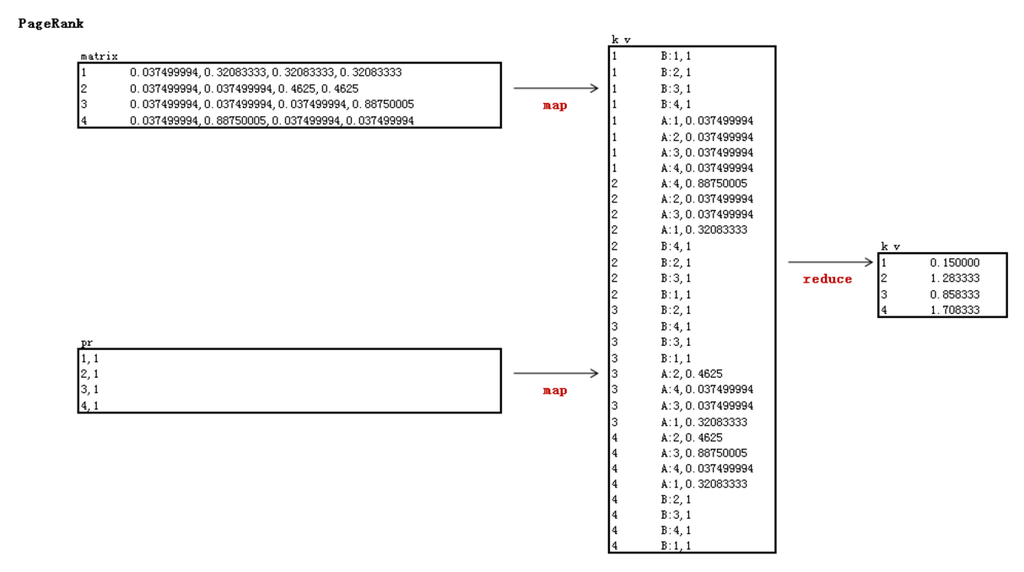

pageRank–mapreduce2